# classe - 5

## Gràfics

- Hem vist al llarg del curs que dibuixar és primordial
- R té moltíssimes maneres de dibuixar, i a més fa dibuixos a nivell de publicació amb relativament poc esforç (“”“”relativament“”“”)
- Hi ha moltes llibreries, però la més utilitzada és “ggplot2”
- N’hi ha d’altres d’interessants: plotly, ggvis, ggforce, etc.
- Si algú està molt interessat, en python hi ha eines més potents: matplotlib, seaborn, etc.

## ggplot2

- El nom prové de Grammar of Graphics, un llibre teòric sobre com es fan els gràfics digitals.
- Tradueix teòricament estètica a píxels.
- Si algú està molt interssat, [aquí](http://www.springer.com/us/book/9780387245447) el pot trobar.
- Un exemple:

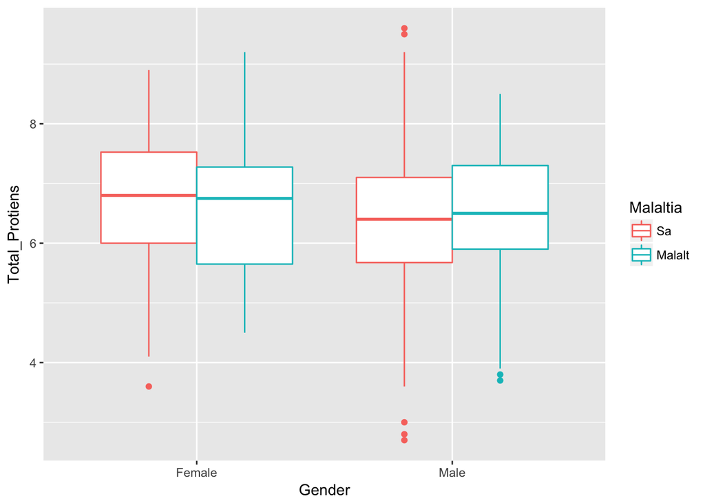

```r
liver = read.csv('indian_liver_patient.csv')
colnames(liver)[ncol(liver)] = "Malaltia"
liver$Malaltia = as.factor(liver$Malaltia)
levels(liver$Malaltia) <- c("Sa","Malalt")
require(ggplot2)
ggplot(liver, aes(x = Gender, y = Total_Protiens, colour = Malaltia)) +
  geom_boxplot()
```

Com funciona:

- La funció ggplot() crea el gràfic i sempre necessita dos paràmetres:
  1. Les dades amb les que fer el gràfic; les posem al principi
  2. Els estètics (aesthetics en anglès, d’aquí el nom): aquí hi posem quina variable volem a l’eix x i y, i si volem colors o formes diferents.
- Per acabar, li diem quin tipus de gràfic volem, en aquest cas un diagrama de caixes (boxplot)

A partir d’aquí hi ha moltíssimes maneres de personalitzar un diagrama:

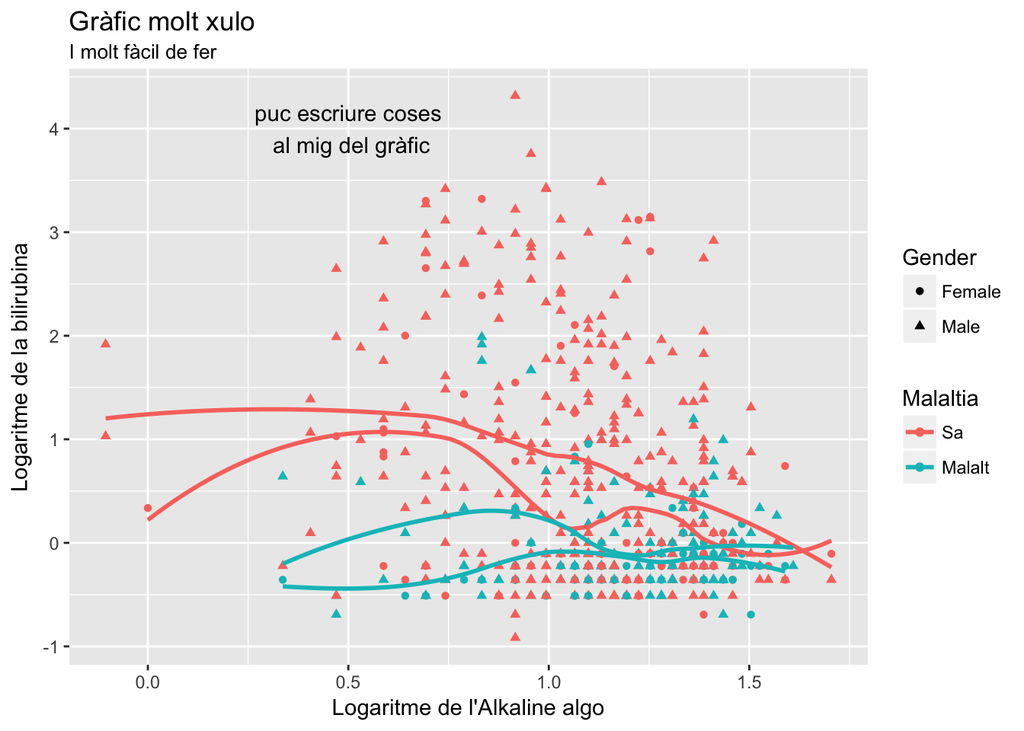

```r
ggplot(liver, aes(x = log(Albumin), y = log(Total_Bilirubin),
                  colour = Malaltia, shape = Gender)) +
  geom_point(size=1.5) +
  labs(title = "Gràfic molt xulo",
       subtitle = "I molt fàcil de fer") +
  xlab("Logaritme de l'Alkaline algo") +
  ylab("Logaritme de la bilirubina") +
  geom_smooth(method = "loess", se = FALSE) +
  theme_gray() +
  annotate("text", x = 0.5, y= 4, label = "puc escriure coses\n al mig del gràfic")
```

```r
for (i in 3:7){
  liver[,i] = log(liver[,i])
}
```

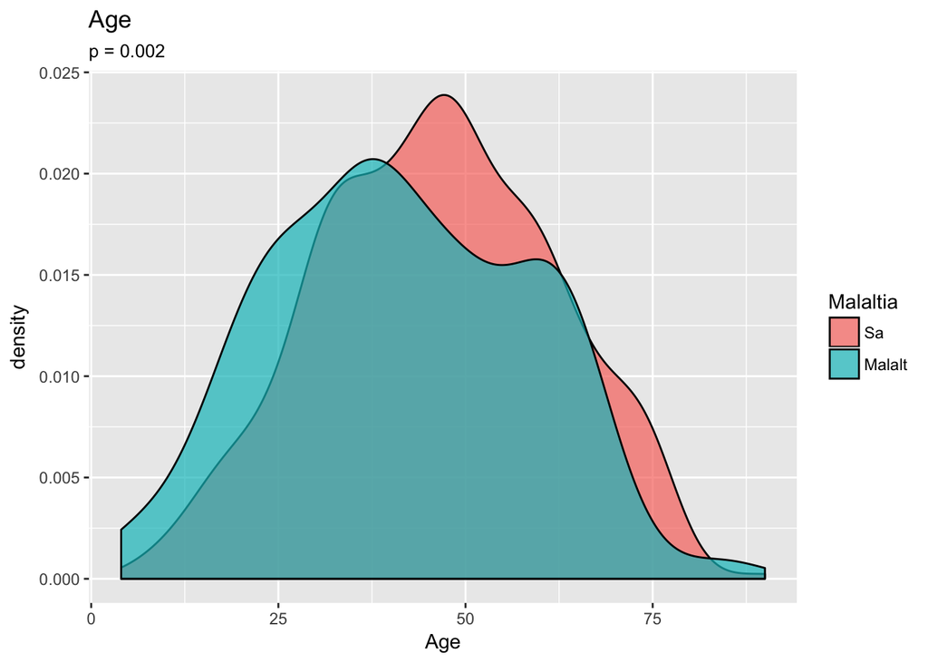

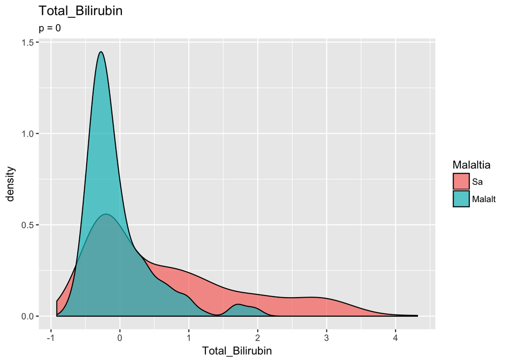

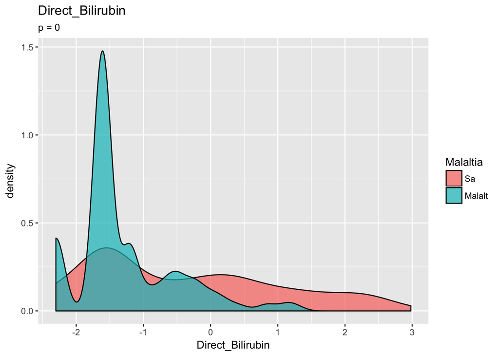

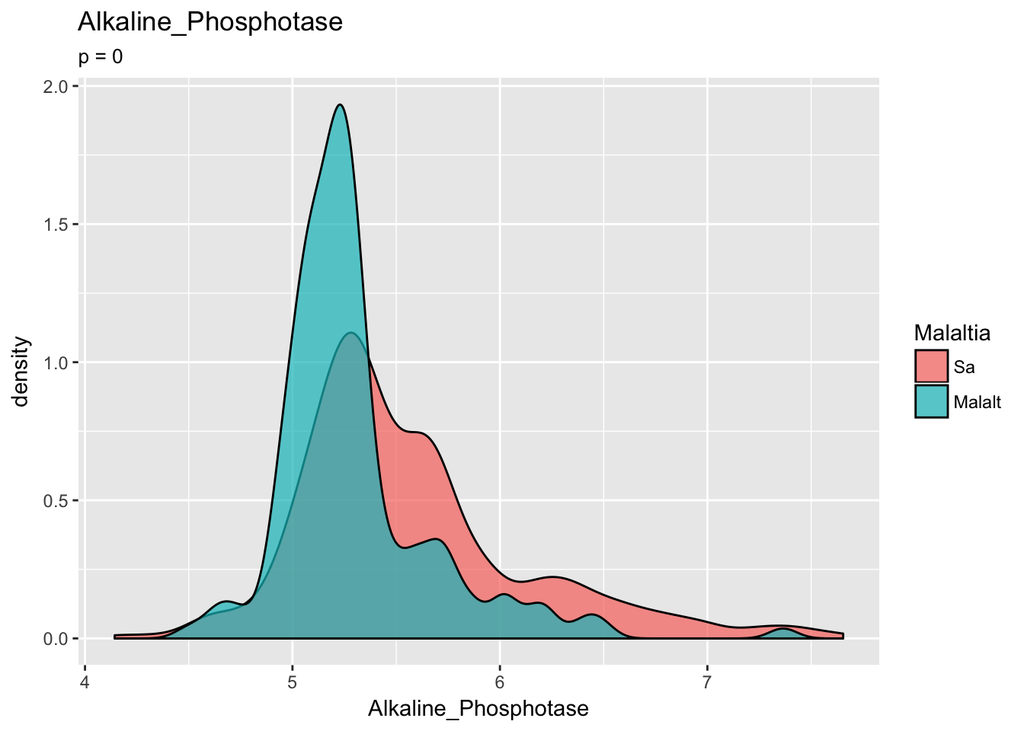

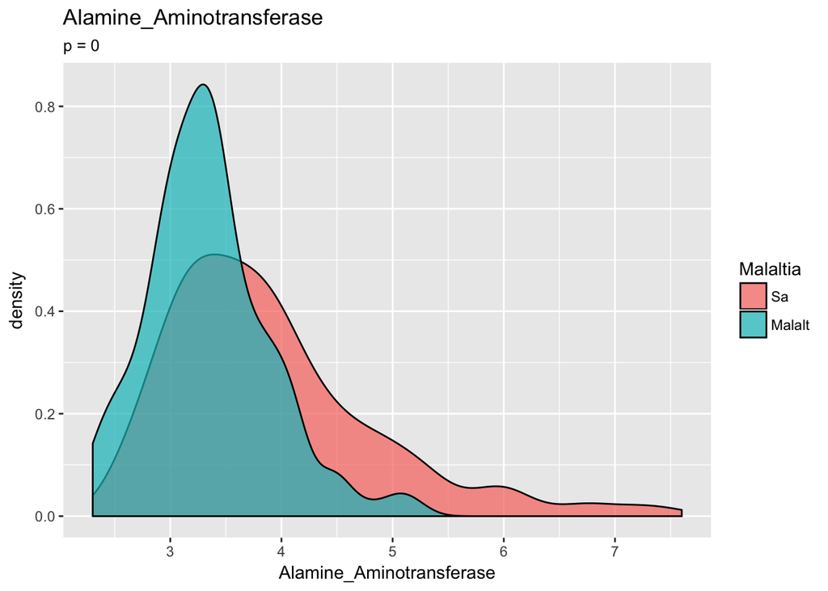

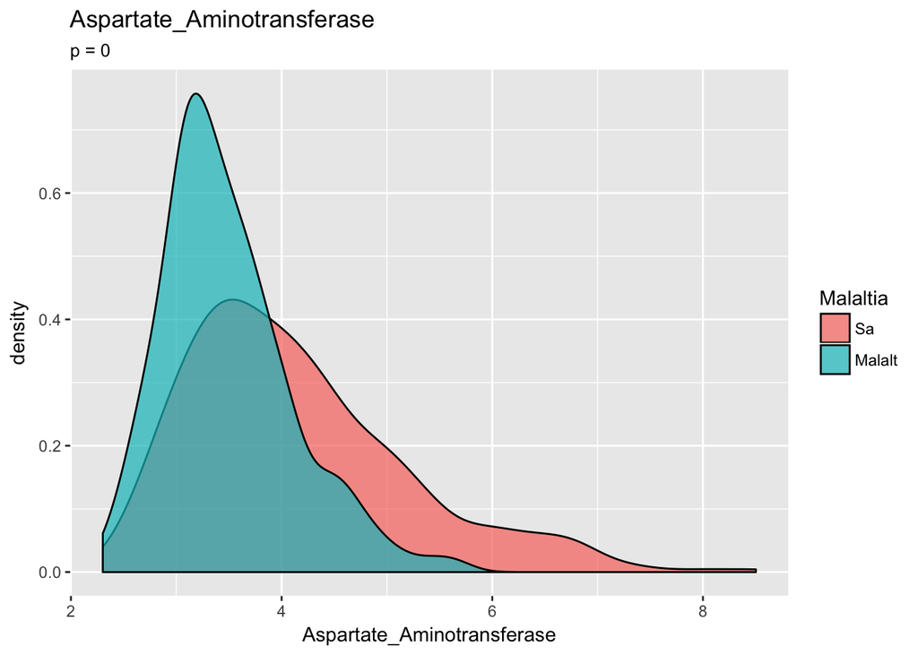

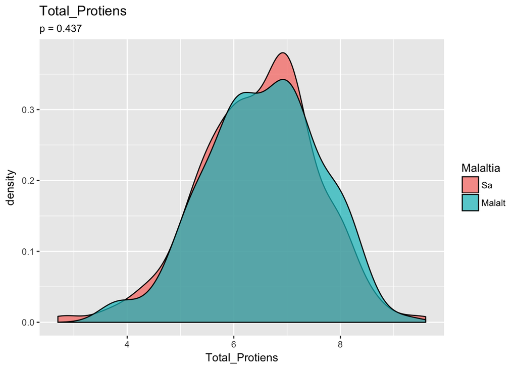

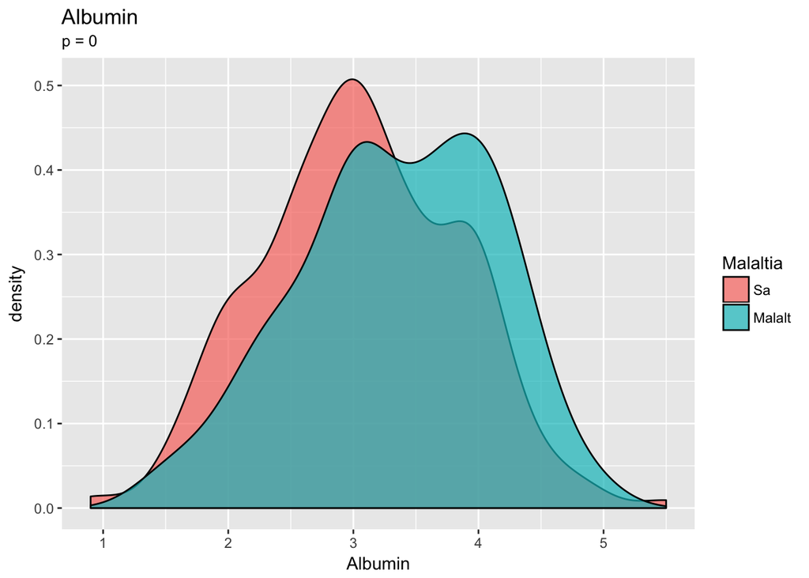

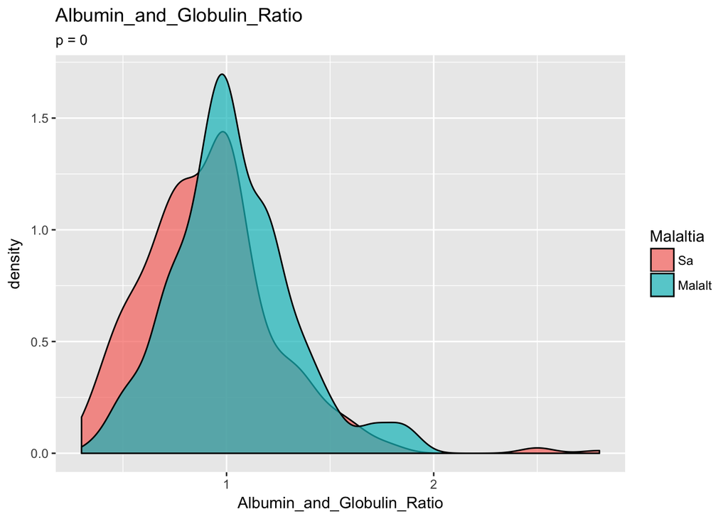

```r
for (i in c(1, 3:10)){

  p=wilcox.test(liver[,i]~liver$Malaltia)$p.value
  #print(rownames(pk)[i-1])
plot = ggplot(liver, aes(liver[,i],  fill=liver$Malaltia)) +
#  geom_histogram(aes(y = ..density..)) +
  geom_density(alpha=0.7)+
  labs(title=colnames(liver)[i],
       subtitle = paste0("p = ",round(p,3))) +
  xlab(colnames(liver)[i]) +
  guides(fill=guide_legend(title="Malaltia"))

#  labs(title = paste0("p = ",pk[i-1,]))

#newplot = ggplot(ccfis ,aes(y=ccfis[,i],  x=ccfis[,1], fill=ccfis[,1])) +
#  geom_boxplot() +
#  labs(title=paste0(colnames(ccfis)[i],"  p = ",round(p,4)))


print(plot)
#print(newplot)
}
```